# Perinatal Baccin Harmony Integration

Irepan Salvador-Martinez

03/11/2021

# 1 About this analysis

Now that we have the supervised annotations from Gretel, I will integrate both perinatal samples to the Baccin data using Harmony.

```r
library(dplyr)
library(Seurat)
library(cowplot)
library(patchwork)
library(ggplot2)
library(BiocStyle)
library(harmony)
library(dittoSeq)
library(RColorBrewer)
```

```r
load("NicheData10x.rda")
NicheData10x <- UpdateSeuratObject(object = NicheData10x)
DimPlot(NicheData10x)
```

Get UMAP udsing the same PCs than the ones used for TSNE (16)

```r
ElbowPlot(NicheData10x)
NicheData10x <- RunUMAP(NicheData10x, dims = 1:16)
DimPlot(NicheData10x, label = T, repel = T) + theme_bw() + NoLegend()
saveRDS(NicheData10x, "NicheData10x_v4_UMAP.rds")
```

# 2 Integrate with Perinatal stages

```r
E18_PN1_Harmony <- readRDS("../3-downstream_analyses/3.2-Integration/E18_PN1_Harmony.rds")
```

## 2.1 Merge datatsets

Before running Harmony, make a Seurat object and following the standard pipeline through PCA.

IMPORTANT DIFFERENCE: In the Seurat integration tutorial, you need to define a Seurat object for each dataset. With Harmony integration, create only one Seurat object with all cells.

```r
E18_PN1_Harmony$Experiment <- "Perinatal"

NicheData10x$Experiment <- "Baccin"
NicheData10x$Cell_Type <- NicheData10x@active.ident

Perinatal_Baccin_Harmony <- merge(E18_PN1_Harmony, y =NicheData10x,
                                  add.cell.ids = c("E18_PN1", "Baccin"),
                                  project = "Perinatal_Baccin_Harmony") %>%
  Seurat::NormalizeData(verbose = FALSE) %>%
  FindVariableFeatures(selection.method = "vst", nfeatures = 3000)

Perinatal_Baccin_Harmony <- ScaleData(Perinatal_Baccin_Harmony, verbose = FALSE,
                                      features= rownames(Perinatal_Baccin_Harmony) ) %>%
  RunPCA(pc.genes = Perinatal_Baccin_Harmony@var.genes, npcs = 30, verbose = FALSE)
```

```r
Perinatal_Baccin_Harmony <- readRDS(file = "Perinatal_Baccin_Harmony.rds")
```

Usually there is a clear difference between the datasets in the uncorrected PCs compared to the corrected ones. Here the uncorrected:

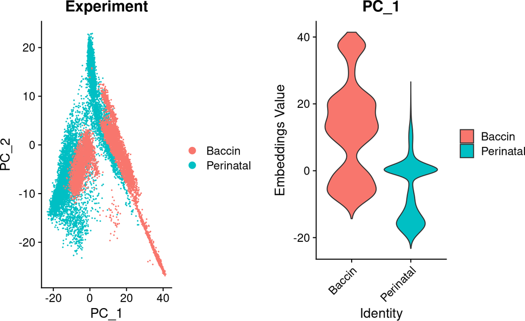

```r
options(repr.plot.height = 5, repr.plot.width = 12)
p1 <- DimPlot(object = Perinatal_Baccin_Harmony, reduction = "pca", pt.size = .1, group.by = "Experiment")
p2 <- VlnPlot(object = Perinatal_Baccin_Harmony, features = "PC_1", group.by = "Experiment", pt.size = 0)
plot_grid(p1,p2)
```

# 3 Run Harmony

The simplest way to run Harmony is to pass the Seurat object and specify which variable(s) to integrate out. RunHarmony returns a Seurat object, updated with the corrected Harmony coordinates. Let’s set plot_convergence to TRUE, so we can make sure that the Harmony objective function gets better with each round.

```r
Perinatal_Baccin_Harmony <- Perinatal_Baccin_Harmony %>%
    RunHarmony("Experiment", plot_convergence = TRUE)
```

[output not shown]

To directly access the new Harmony embeddings, use the Embeddings command.

```r
harmony_embeddings <- Embeddings(Perinatal_Baccin_Harmony, 'harmony')
harmony_embeddings[1:5, 1:5]
```

```
##                                 harmony_1 harmony_2 harmony_3 harmony_4  harmony_5
## E18_PN1_E18_AAACCCAAGGGTAATT-1 -13.605828 -9.370166  4.659688 -3.362152 -0.4483049
## E18_PN1_E18_AAACCCACAGTTAAAG-1   7.652449  7.917900  3.641280  6.320300 -3.6221584
## E18_PN1_E18_AAACCCACATCCGATA-1   3.926124  6.237306  6.240431 10.558172 12.7330506
## E18_PN1_E18_AAACCCAGTATCGATC-1   7.298181  6.380011  4.079165  3.417594 -3.6160667
## E18_PN1_E18_AAACCCAGTCAAATCC-1  -9.529706 -5.391189  3.868708 -3.024208 -3.1421480
```

Let’s make sure that the datasets are well integrated in the first 2 dimensions after Harmony.

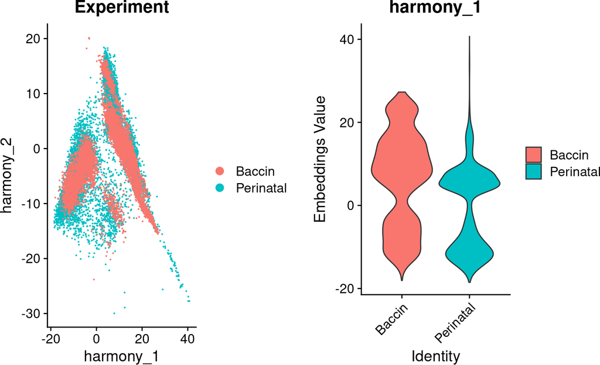

```r
p1 <- DimPlot(object = Perinatal_Baccin_Harmony, reduction = "harmony", pt.size = .1, group.by = "Experiment")
p2 <- VlnPlot(object = Perinatal_Baccin_Harmony, features = "harmony_1", group.by = "Experiment", pt.size = 0)
plot_grid(p1,p2)
```

# 4 Downstream analysis

## 4.1 FindNeighbours and UMAP

Many downstream analyses are performed on low dimensional embeddings, not gene expression. To use the corrected Harmony embeddings rather than PCs, set reduction = ‘harmony’. For example, let’s perform the UMAP and Nearest Neighbor analyses using the Harmony embeddings.

```r
Perinatal_Baccin_Harmony <- Perinatal_Baccin_Harmony %>%
    RunUMAP(reduction = "harmony", dims = 1:30) %>%
    FindNeighbors(reduction = "harmony", dims = 1:30) %>%
    FindClusters(resolution = 0.4) %>%
    identity()
```

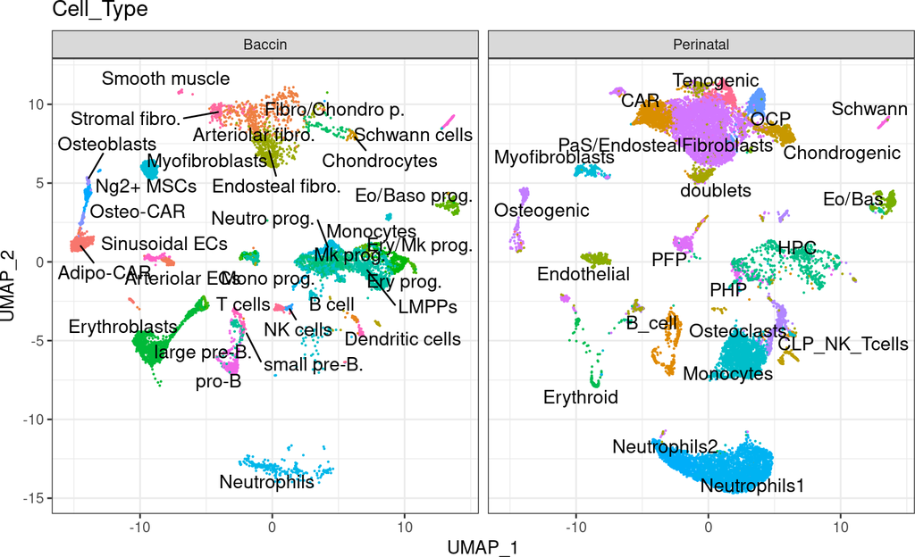

```r
Perinatal_Baccin_Harmony@meta.data$Cell_Type <- as.character(Perinatal_Baccin_Harmony@meta.data$Cell_Type)
DimPlot(Perinatal_Baccin_Harmony,
        group.by = "Cell_Type",
        split.by = "Experiment",
        label = T, repel = T) * theme_bw()  * NoLegend()
```

# 5 Export RDS for visualisation

```r
source("../../utils/seurat2shiny.R")
seurat2shiny(Perinatal_Baccin_Harmony, reduction = "umap",
             save = TRUE, name ="Perinatal_Baccin_Harmony")
```

# 6 Save for later

```r
saveRDS(Perinatal_Baccin_Harmony, file = "Perinatal_Baccin_Harmony.rds")
```

# 7 Sessio Info